# NIAID-1418 Spectral Signature Analysis

5-Laser vs 6-Laser Configuration and Fixation Effects

## 0.1 Project Goals

**Dataset analysed in this report:** 83c colour set. Results folder: `spectral_analysis_results_83c_filtered`.

*The project goals below are copied exactly from the RTB Flow Core Slide Deck.*

- **Main goal:** Impact of number of lasers (5L x 6L) and fixation in panel resolution in the spectral signature of fluorochromes
- **Specific aims:**
  1. **Instrument configuration:**
     - 1. Peak shift?
     - 2. Is similarity between fluors constant?
  2. **Fixation impact:**
     - 1. Overall impact of each treatment – any worse?
     - 2. Type of fluor more susceptible?
     - 3. Impact of number of lasers

# 1 Q1 — Instrument configuration

## 1.1 Q1a — Do spectral peaks shift?

**Answer to Q1a:**

**The detector containing the maximum spectral signal did not differ between 5L and 6L, and treatment-associated changes in the maximum detector were uncommon.** The percentage of fluorochrome × treatment comparisons that remained **Stable** was 89.6% for 1% PFA, 94.0% for 4% PFA, 97.0% for Perm. Configuration-only peak differences accounted for 0.0% of cases. Treatment-associated peak changes affecting both 5L and 6L occurred in 3.0–10.4% of cases, while configuration-specific treatment effects (5L only or 6L only) accounted for 0.0–3.0%. Importantly, a change in maximum detector or laser assignment is not necessarily a change in the fluorochrome’s underlying emission-peak wavelength. Near-tied maxima should also be interpreted cautiously because small differences between nearly equal detector values can change which detector is identified as the maximum.

The results below separate configuration-only peak differences from treatment-associated peak changes and stable spectra. **Definitions and criteria for each reporting category are provided in the Appendix.**

Q1a — peak-behavior categories by treatment

| Treatment | Reporting category | N | Percent (%) |
| --- | --- | --- | --- |
| 1% PFA | Configuration Only – dUV Block Difference | 0 | 0.0 |
| 1% PFA | Configuration Only – Comparable Area | 0 | 0.0 |
| 1% PFA | Treatment Effect – 5L Only | 0 | 0.0 |
| 1% PFA | Treatment Effect – 6L Only | 0 | 0.0 |
| 1% PFA | Treatment Effect – Both Configurations | 7 | 10.4 |
| 1% PFA | Stable | 60 | 89.6 |
| 4% PFA | Configuration Only – dUV Block Difference | 0 | 0.0 |
| 4% PFA | Configuration Only – Comparable Area | 0 | 0.0 |
| 4% PFA | Treatment Effect – 5L Only | 2 | 3.0 |
| 4% PFA | Treatment Effect – 6L Only | 0 | 0.0 |
| 4% PFA | Treatment Effect – Both Configurations | 2 | 3.0 |
| 4% PFA | Stable | 63 | 94.0 |
| Perm | Configuration Only – dUV Block Difference | 0 | 0.0 |
| Perm | Configuration Only – Comparable Area | 0 | 0.0 |
| Perm | Treatment Effect – 5L Only | 0 | 0.0 |
| Perm | Treatment Effect – 6L Only | 0 | 0.0 |
| Perm | Treatment Effect – Both Configurations | 2 | 3.0 |
| Perm | Stable | 65 | 97.0 |

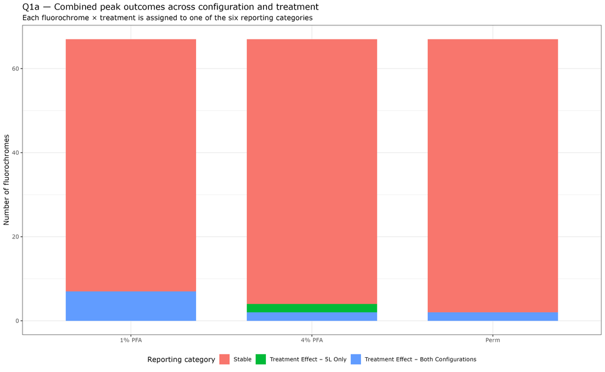

Links to the corresponding plots are provided in the last column of the table for each relevant fluorochrome row. Each row links to the plot(s) that fit its reporting category (5L vs 6L for configuration-only differences, 5L or 6L for single-configuration treatment effects, both for effects in both configurations); all plots are in the `Q1a_plots` folder on GitHub.

[output not shown]

[output cut: 191 more lines]

### 1.1.1 Q1a — Expected vs observed peak-detector assignment

*The Sony Spectral Viewer validation is only available for the 63c colour set (the Sony workbook contains observed peak detectors for the 63c matrices only), so it is not included for this dataset.*

## 1.2 Q1b — Is similarity between fluorochromes constant?

**Answer to Q1b:**

**Across the 4 conditions, fluorochrome similarity was generally stable between 5L and 6L, but it was not identical.** Cosine similarity measures how similar the spectral shapes of two fluorochromes are, where values closer to 1 indicate more similar spectra. For each condition, pairwise cosine similarity was compared directly between the 5L and 6L configurations.

Across conditions, the median absolute difference in pairwise cosine similarity between 5L and 6L was **0.0005–0.0010**. The number of highly similar fluorochrome pairs (cosine similarity ≥ 0.90) per treatment was 97/97/99/97 in 5L versus 97/97/99/99 in 6L (in the order 1% PFA, 4% PFA, Perm, Unfixed).

The **largest single-pair differences** among the treatments were: **1% PFA = 0.008, 4% PFA = 0.020, Perm = 0.020**. Compared with the typical (median) difference, a few specific fluorochrome pairs can show much larger differences between the two configurations.

**Cosine similarity** is the primary measure. Cosine similarity was used to quantify the similarity between fluorochrome spectral signatures across detectors. In spectral flow cytometry, cosine similarity provides a pairwise measure of spectral overlap, with values approaching 1 indicating increasingly similar spectral shapes. This metric is commonly used for evaluating fluorochrome similarity, panel design, and spectral stability (Jensen et al., 2021; Rajwa et al., 2025; Mage et al., 2026). Values approaching 1 indicate increasingly similar spectral shapes. The clustered heatmaps show broader spectral neighborhoods; the pairwise table gives the exact 5L and 6L cosine similarity for each pair of different fluorochromes.

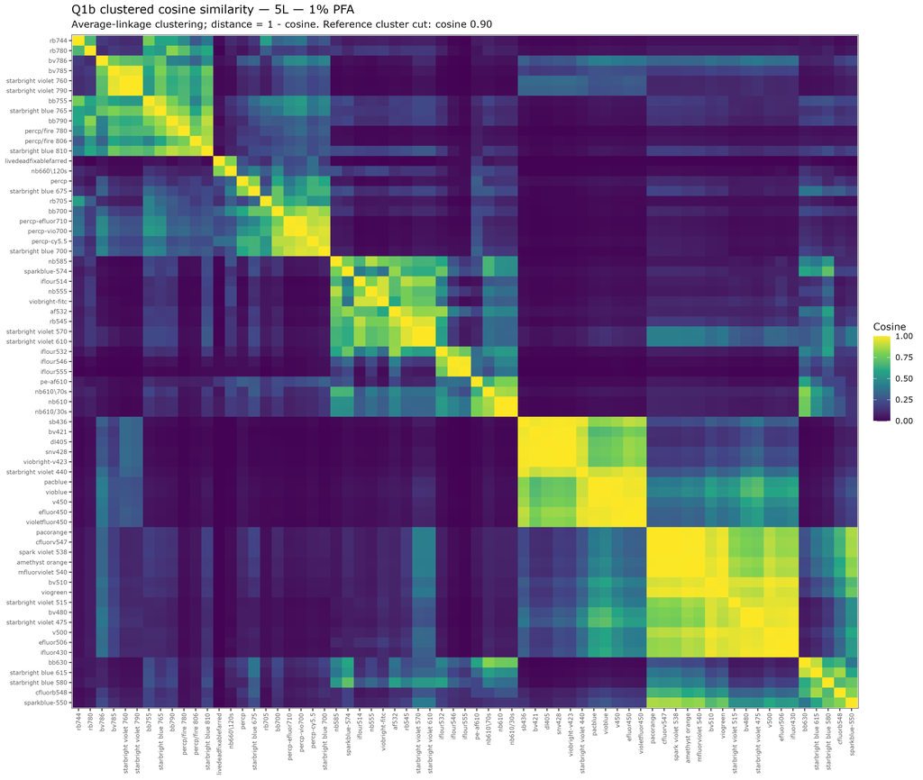

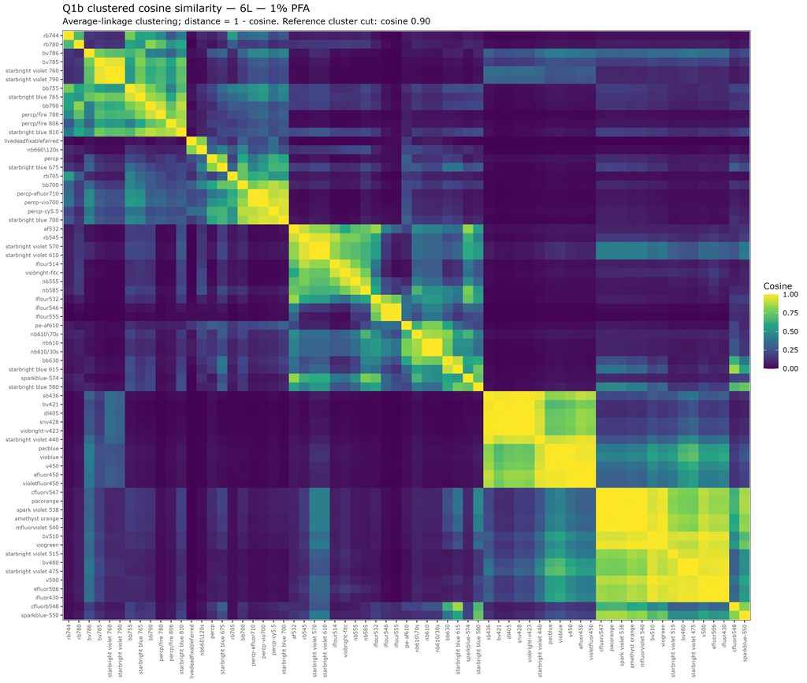

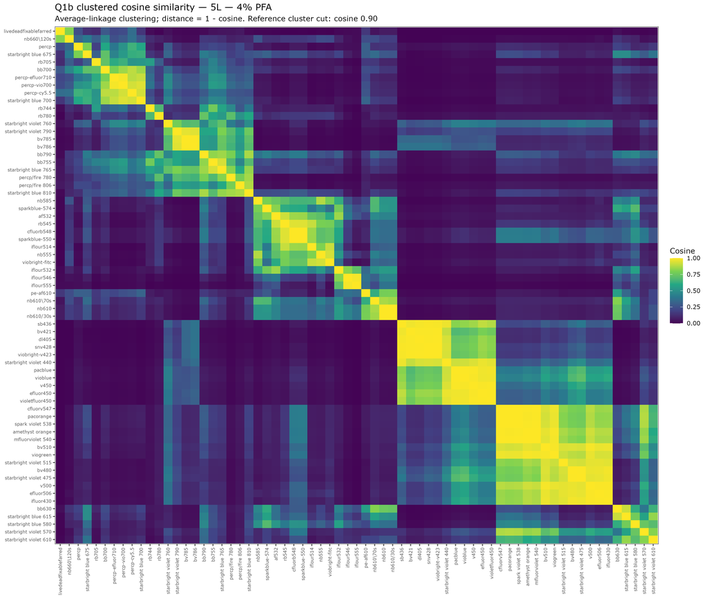

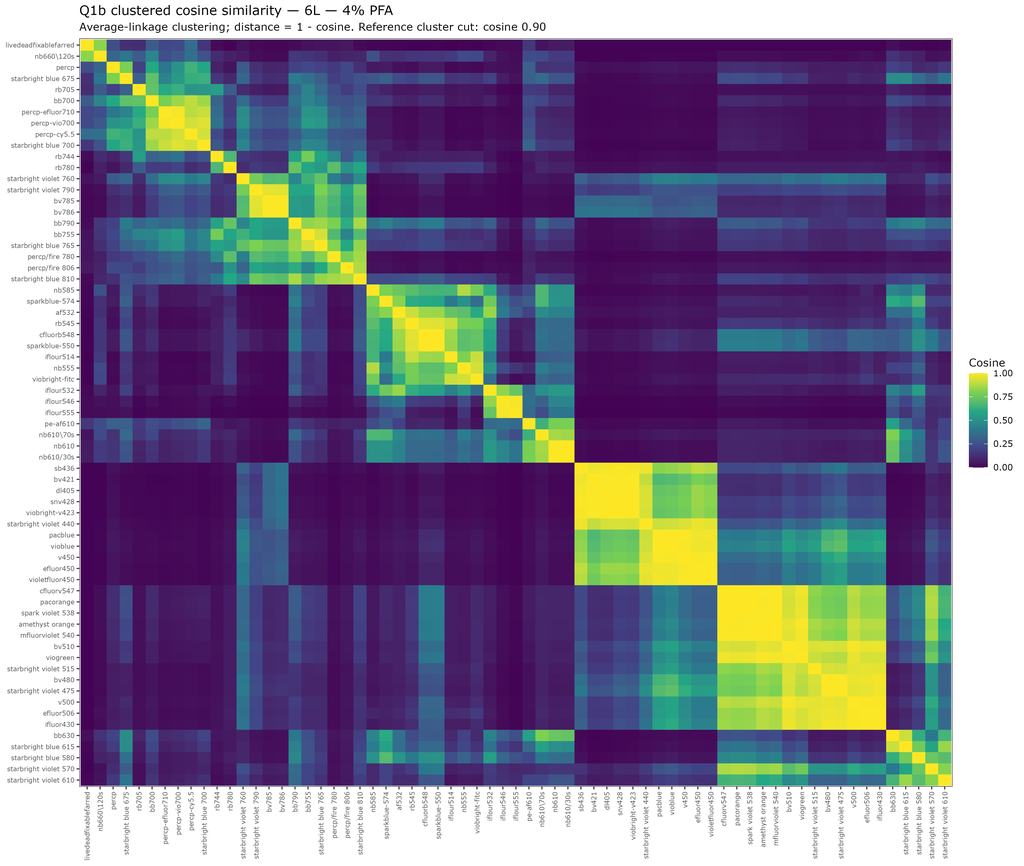

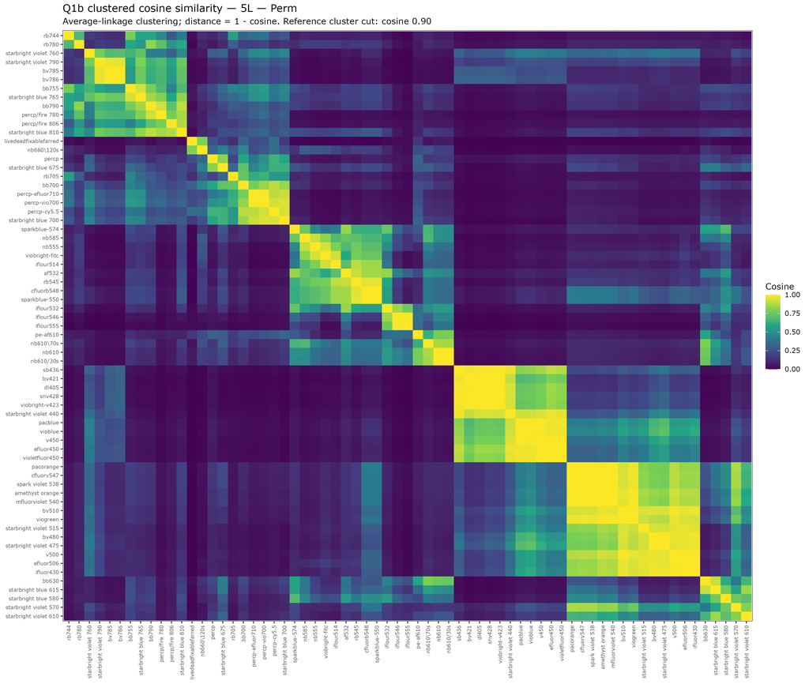

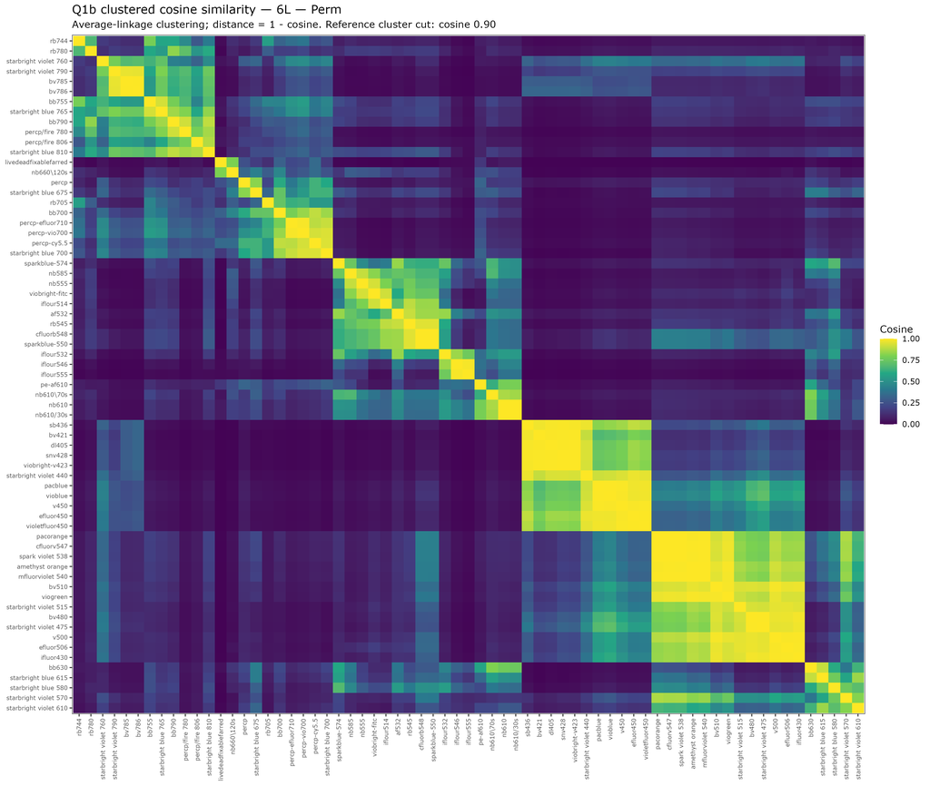

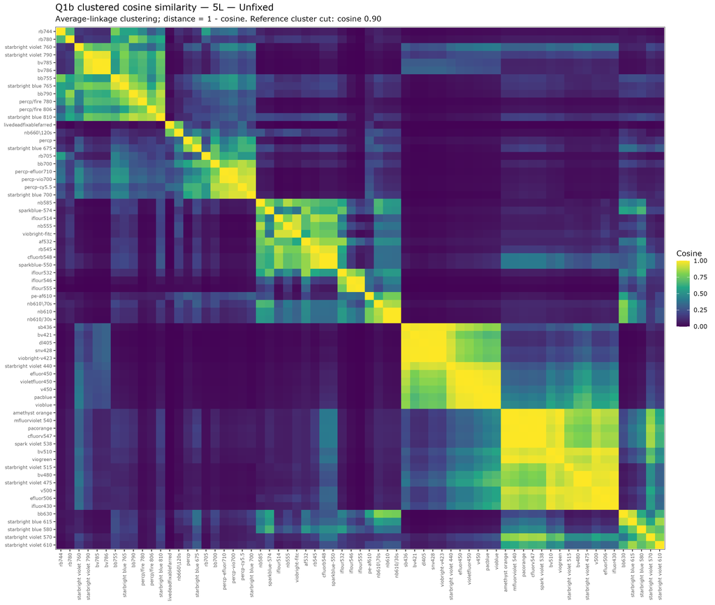

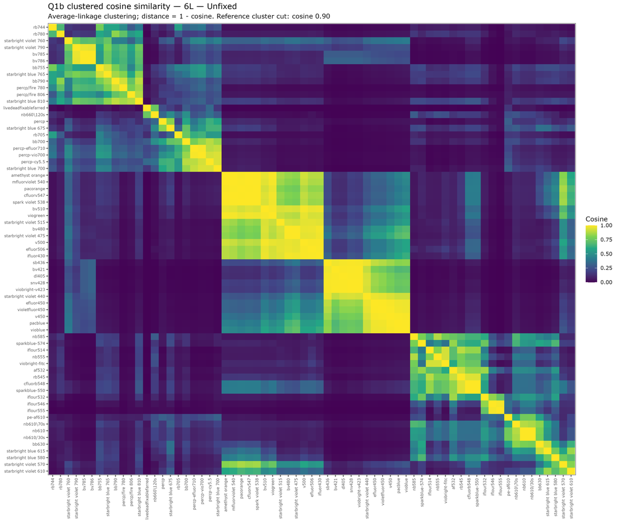

| Treatment | Fluor_A | Fluor_B | Cosine_5L | Cosine_6L | Delta_cosine_5L_minus_6L | Abs_delta_cosine | >=0.90 in 5L | >=0.90 in 6L | >=0.90 in both | >=0.90 in either | Highest_cosine |
| --- | --- | --- | --- | --- | --- | --- | --- | --- | --- | --- | --- |
| 1% PFA | starbright violet 570 | starbright violet 610 | 0.9999621159046784 | 0.9999601756303628 | 1.940274315881396e-06 | 1.940274315881396e-06 | True | True | True | True | 0.9999621159046784 |
| 1% PFA | spark violet 538 | cfluorv547 | 0.9998822893359312 | 0.9998471195907006 | 3.51697452305455e-05 | 3.51697452305455e-05 | True | True | True | True | 0.9998822893359312 |
| 1% PFA | pacorange | spark violet 538 | 0.9998804859202296 | 0.9998784806002644 | 2.00531996530362e-06 | 2.00531996530362e-06 | True | True | True | True | 0.9998804859202296 |
| 1% PFA | pacorange | cfluorv547 | 0.9995985834866792 | 0.999527759258688 | 7.08242279914284e-05 | 7.08242279914284e-05 | True | True | True | True | 0.9995985834866792 |
| 1% PFA | nb610 | nb610/30s | 0.9995166044140236 | 0.9995496155368148 | -3.301112279141538e-05 | 3.301112279141538e-05 | True | True | True | True | 0.9995496155368148 |
| 1% PFA | mfluorviolet 540 | amethyst orange | 0.9993790677420236 | 0.9994060995039552 | -2.703176193163958e-05 | 2.703176193163958e-05 | True | True | True | True | 0.9994060995039552 |
| 1% PFA | viobright-v423 | snv428 | 0.9993781467865368 | 0.9993864825436194 | -8.33575708270029e-06 | 8.33575708270029e-06 | True | True | True | True | 0.9993864825436194 |
| 1% PFA | starbright violet 760 | starbright violet 790 | 0.999051775393358 | 0.998908081071366 | 0.0001436943219922382 | 0.0001436943219922382 | True | True | True | True | 0.999051775393358 |
| 1% PFA | efluor450 | violetfluor450 | 0.9988562194451384 | 0.9988402633118 | 1.595613333826851e-05 | 1.595613333826851e-05 | True | True | True | True | 0.9988562194451384 |
| 1% PFA | mfluorviolet 540 | cfluorv547 | 0.9984726715322264 | 0.9986473753238873 | -0.0001747037916609573 | 0.0001747037916609573 | True | True | True | True | 0.9986473753238873 |

[output cut: 8834 more lines]

# 2 Q2 — Fixation impact

## 2.1 Q2a — What is the overall impact of each treatment?

**Answer to Q2a:**

**The treatment ranking by overall impact differed between 5L and 6L.** Median RMSE ordering differed between configurations: 5L: **4% PFA > Perm > 1% PFA** (0.0045 > 0.0034 > 0.0029); 6L: **Perm > 4% PFA > 1% PFA** (0.0039 > 0.0034 > 0.0030). Because higher RMSE indicates greater deviation from the corresponding Unfixed spectrum, a higher median RMSE means a larger spectral change. Treatment differences were statistically significant in both configurations (Friedman: 5L P < 0.001, Kendall W = 0.141; 6L P < 0.001, Kendall W = 0.104). 0 of 6 pairwise treatment comparisons remained significant after BH correction; the largest separation was between 1% PFA and 4% PFA in 5L and 1% PFA and Perm in 6L.

Each treated spectrum is compared with the **corresponding Unfixed spectrum in the same configuration**. RMSE is the primary magnitude measure: higher RMSE means a larger treatment-associated spectral change.

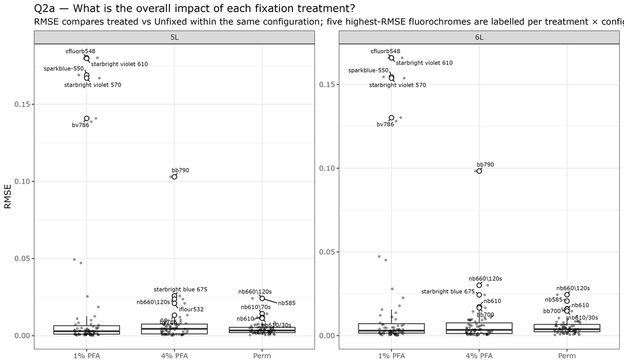

Q2a — overall treatment comparison

| Config | Test | N_fluorochromes | Statistic | df | P value | Kendall W |
| --- | --- | --- | --- | --- | --- | --- |
| 5L | Friedman (RMSE blocked by fluorochrome) | 67 | 18.836 | 2 | < 0.001 | 0.141 |
| 6L | Friedman (RMSE blocked by fluorochrome) | 67 | 14.000 | 2 | < 0.001 | 0.104 |

| Config | Treatment_A | Treatment_B | N_pairs | Median_RMSE_A | Median_RMSE_B | Median_paired_difference | Rank-biserial r | P | P (BH) | Direction |
| --- | --- | --- | --- | --- | --- | --- | --- | --- | --- | --- |
| 5L | 1% PFA | 4% PFA | 67 | 0.0029 | 0.0045 | -0.0004 | -0.2836 | 0.044 | 0.132 | No detectable difference |
| 5L | 1% PFA | Perm | 67 | 0.0029 | 0.0034 | -0.0006 | -0.2318 | 0.100 | 0.150 | No detectable difference |
| 5L | 4% PFA | Perm | 67 | 0.0045 | 0.0034 | 0 | 0.1396 | 0.322 | 0.322 | No detectable difference |
| 6L | 1% PFA | Perm | 67 | 0.003 | 0.0039 | -0.0005 | -0.2054 | 0.145 | 0.434 | No detectable difference |
| 6L | 1% PFA | 4% PFA | 67 | 0.003 | 0.0034 | -0.0001 | -0.0878 | 0.534 | 0.534 | No detectable difference |
| 6L | 4% PFA | Perm | 67 | 0.0034 | 0.0039 | -0.0002 | -0.1106 | 0.433 | 0.534 | No detectable difference |

## 2.2 Q2b — Are particular fluorochromes or fluorochrome types more susceptible?

**Answer to Q2b:**

**Susceptibility differs among individual fluorochromes (see the ranking table).** Based on mean fixation-associated RMSE across treatments, the highest-ranked fluorochromes were in 5L: **cfluorb548, starbright violet 610, starbright violet 570**; in 6L: **cfluorb548, starbright violet 610, starbright violet 570**. At the family level, no comparison remained significant after BH correction. The smallest unadjusted P was 0.012 (6L 4% PFA, ε² = 0.392). Family assignments come from the curated annotation table; fluorochromes flagged Needs_review are excluded from the family-level test, and the family-level conclusions remain provisional where assignments are still unresolved.

The individual ranking identifies fluorochromes with larger fixation-associated changes. The family analysis asks whether RMSE differs systematically among fluorochrome families.

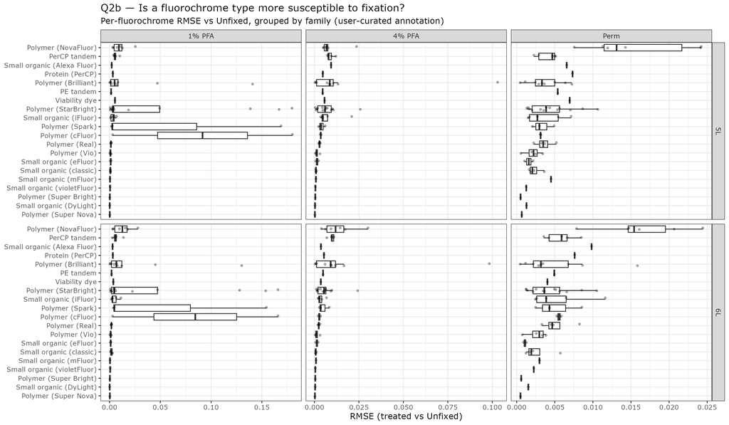

Q2b — fluorochrome-family susceptibility test

| Config | Treatment | N_families | N_fluorochromes | Chi-squared | df | P | P (BH) | Epsilon squared |
| --- | --- | --- | --- | --- | --- | --- | --- | --- |
| 5L | 1% PFA | 7 | 43 | 11.844 | 6 | 0.066 | 0.131 | 0.282 |
| 5L | 4% PFA | 7 | 43 | 12.958 | 6 | 0.044 | 0.131 | 0.309 |
| 5L | Perm | 7 | 43 | 2.901 | 6 | 0.821 | 0.821 | 0.069 |
| 6L | 1% PFA | 7 | 43 | 8.492 | 6 | 0.204 | 0.306 | 0.202 |
| 6L | 4% PFA | 7 | 43 | 16.447 | 6 | 0.012 | 0.069 | 0.392 |
| 6L | Perm | 7 | 43 | 5.020 | 6 | 0.541 | 0.649 | 0.120 |

| Config | Fluor_ID | Mean_RMSE | Median_RMSE | Mean_Pearson | Mean_Cosine | Mean_max_abs_detector_difference | Mean_abs_intensity_change_percent | Mean_abs_peak_shift_nm | Rank_RMSE | Rank_Pearson_disruption | Rank_Cosine_disruption | Rank_Max_difference | Rank_Intensity_change | Rank_Peak_shift |
| --- | --- | --- | --- | --- | --- | --- | --- | --- | --- | --- | --- | --- | --- | --- |
| 5L | af532 | 0.00601786187102019 | 0.00656129376455912 | 0.998888380856161 | 0.9989029963820184 | 0.03595758666666669 |  | 0 | 24 | 18 | 18 | 24 | 1 | 11 |
| 5L | amethyst orange | 0.00236736519925359 | 0.00221670037592122 | 0.9999453665650984 | 0.999943408683686 | 0.01443013333333335 |  | 0 | 45 | 49 | 49 | 46 | 2 | 11 |
| 5L | bb630 | 0.00478885831780309 | 0.00363070967563538 | 0.9995967432808328 | 0.9996538909528492 | 0.03422556666666668 |  | 0 | 31 | 29 | 30 | 25 | 3 | 11 |
| 5L | bb700 | 0.00769000388299136 | 0.00724317665020276 | 0.999418703695311 | 0.9995631439253052 | 0.04140406666666663 |  | 0 | 20 | 24 | 24 | 21 | 4 | 11 |
| 5L | bb755 | 0.00616878414483456 | 0.00638484816663874 | 0.9996249687357692 | 0.9997170268139274 | 0.02347023333333335 |  | 0 | 22 | 31 | 33 | 33 | 5 | 11 |
| 5L | bb790 | 0.03878682685548251 | 0.00837550736622989 | 0.9700566899576116 | 0.9762858074574748 | 0.1501906333333334 |  | 0 | 7 | 7 | 7 | 10 | 6 | 11 |
| 5L | bv421 | 0.0003192687768396614 | 0.0002957839659062912 | 0.999994497162762 | 0.9999946140467462 | 0.00285491999999997 |  | 0 | 67 | 67 | 67 | 66 | 7 | 11 |
| 5L | bv480 | 0.000976790832617985 | 0.00103907527314093 | 0.9999804617786608 | 0.9999813724986004 | 0.01024313333333326 |  | 0 | 59 | 63 | 63 | 56 | 8 | 11 |
| 5L | bv510 | 0.00159552614903508 | 0.0012211593184273 | 0.9999671734094688 | 0.999969425091754 | 0.01713226666666663 |  | 0 | 51 | 57 | 58 | 40 | 9 | 11 |
| 5L | bv785 | 0.02036491196904497 | 0.01060669689107882 | 0.9876339710233584 | 0.9887887749314844 | 0.17016821 |  | 0 | 10 | 9 | 9 | 7 | 10 | 11 |

[output cut: 124 more lines]

## 2.3 Q2c — Does the impact of fixation differ between 5L and 6L?

For the same fluorochrome and treatment, fixation RMSE in 5L is compared directly with fixation RMSE in 6L. The 1:1 line represents equal measured fixation effect in the two configurations.

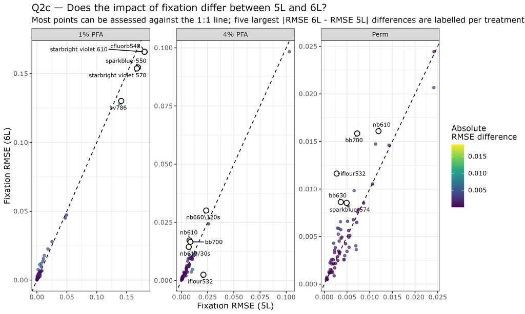

| Treatment | Fluor_ID | RMSE_5L | RMSE_6L | Pearson_5L | Pearson_6L | Cosine_5L | Cosine_6L | Max_abs_detector_difference_5L | Max_abs_detector_difference_6L | Total_intensity_change_percent_5L | Total_intensity_change_percent_6L | Peak_shift_nm_5L | Peak_shift_nm_6L | Abs_peak_shift_nm_5L | Abs_peak_shift_nm_6L | Delta_RMSE_6L_minus_5L | Delta_Pearson_6L_minus_5L | Delta_Cosine_6L_minus_5L | Delta_Max_difference_6L_minus_5L | Delta_Intensity_change_percent_6L_minus_5L | Delta_Peak_shift_nm_6L_minus_5L |
| --- | --- | --- | --- | --- | --- | --- | --- | --- | --- | --- | --- | --- | --- | --- | --- | --- | --- | --- | --- | --- | --- |
| 1% PFA | bv421 | 0.0002135918696721981 | 0.000289128697067717 | 0.999997976167409 | 0.9999952583605116 | 0.9999980238463844 | 0.9999953563010942 | 0.00220539999999991 | 0.00327279999999996 |  |  | 0 | 0 | 0 | 0 | 7.553682739551895e-05 | -2.717806897423181e-06 | -2.667545290102602e-06 | 0.00106740000000005 |  | 0 |
| 1% PFA | viobright-v423 | 0.0003487077332570309 | 0.0004206880325889453 | 0.9999953086073492 | 0.9999906421784416 | 0.9999954386858894 | 0.9999908739327976 | 0.00340740000000006 | 0.00445800000000007 |  |  | 0 | 0 | 0 | 0 | 7.198029933191442e-05 | -4.666428907396103e-06 | -4.564753091629292e-06 | 0.00105060000000001 |  | 0 |
| 1% PFA | snv428 | 0.0002355621758362934 | 0.0003130933671520838 | 0.999997548014016 | 0.9999944715496524 | 0.9999976202438648 | 0.999994607196137 | 0.00192360000000002 | 0.00297200000000008 |  |  | 0 | 0 | 0 | 0 | 7.753119131579032e-05 | -3.076464363482856e-06 | -3.013047727762341e-06 | 0.00104840000000006 |  | 0 |
| 1% PFA | sb436 | 0.0002724176121208231 | 0.0003405067691680473 | 0.9999973136545364 | 0.9999941060472174 | 0.9999974067397952 | 0.9999942736924384 | 0.00232529999999997 | 0.003199 |  |  | 0 | 0 | 0 | 0 | 6.808915704722426e-05 | -3.207607319088979e-06 | -3.133047356995711e-06 | 0.0008737000000000328 |  | 0 |
| 1% PFA | dl405 | 0.0001893759844811521 | 0.0001392675673509128 | 0.9999984460596584 | 0.9999990015022816 | 0.9999983810934694 | 0.9999988889662146 | 0.00123539999999999 | 0.0006932280000000002 |  |  | 0 | 0 | 0 | 0 | -5.010841713023933e-05 | 5.55442623229041e-07 | 5.078727451923726e-07 | -0.0005421719999999975 |  | 0 |
| 1% PFA | starbright violet 440 | 0.0007020422003392764 | 0.0007427108307295873 | 0.9999872244436736 | 0.9999814550773782 | 0.9999873722467952 | 0.9999816404766576 | 0.00499769999999999 | 0.00537340000000002 |  |  | 0 | 0 | 0 | 0 | 4.066863039031091e-05 | -5.769366295260703e-06 | -5.7317701378512e-06 | 0.0003757000000000343 |  | 0 |
| 1% PFA | vioblue | 0.0007404722463000776 | 0.00107860501985642 | 0.9999846887065628 | 0.9999618783411376 | 0.9999853203578228 | 0.9999633712990084 | 0.00558380000000002 | 0.0082894 |  |  | 0 | 0 | 0 | 0 | 0.0003381327735563432 | -2.281036542506332e-05 | -2.194905881425235e-05 | 0.00270559999999997 |  | 0 |
| 1% PFA | v450 | 0.0008432951916452743 | 0.00288957389904495 | 0.999977627828267 | 0.99957892886255 | 0.9999784497216416 | 0.9995918869963322 | 0.00557369999999995 | 0.0375014414 |  |  | 0 | 0 | 0 | 0 | 0.00204627870739968 | -0.0003986989657170925 | -0.0003865627253094583 | 0.03192774140000004 |  | 0 |
| 1% PFA | efluor450 | 0.0006225925416320382 | 0.0008616268714313649 | 0.9999859830590252 | 0.99996494447331 | 0.9999847386673038 | 0.999961953639827 | 0.00392380000000003 | 0.00678279999999997 |  |  | 0 | 0 | 0 | 0 | 0.0002390343297993267 | -2.103858571522732e-05 | -2.278502747676825e-05 | 0.00285899999999994 |  | 0 |
| 1% PFA | pacblue | 0.0007934600286444568 | 0.00118301286319362 | 0.9999848310386126 | 0.9999441695302288 | 0.9999852463002168 | 0.999946265108552 | 0.00683880000000003 | 0.012988904 |  |  | 0 | 0 | 0 | 0 | 0.000389552834549164 | -4.066150838377691e-05 | -3.898119166467762e-05 | 0.00615010399999996 |  | 0 |

[output cut: 191 more lines]

# 3 Appendix

## 3.1 A1. Q1a reporting category definitions

The six Q1a categories form a **treatment-focused, mutually exclusive classification**, with **Unfixed serving as the baseline/reference**. A treatment-associated peak change takes priority in category assignment: if treatment changes the maximum in 5L and/or 6L, the row is assigned to a **Treatment Effect** category. The **Configuration Only** categories are used only when neither configuration shows a treatment-associated change; the 5L-versus-6L comparison then determines whether a configuration-associated difference remains. **Stable** indicates neither a treatment-associated nor configuration-associated peak change.

The term **Comparable Area** can also appear in the separate comparison-area fields for treatment-effect rows; in that context it means only that the differing 5L and 6L maxima occur in laser regions available in both configurations. It does **not** change the row’s primary treatment-effect category. Likewise, **dUV Block Difference** refers specifically to a configuration-associated difference involving the **320-nm dUV laser block**, which is present in 6L and absent from 5L.

| Reporting category | Definition |
| --- | --- |
| **Configuration Only – dUV Block Difference** | No treatment-associated peak change is detected, but the 6L maximum occurs in the **320-nm dUV laser block**, which is absent from the 5L configuration. The corresponding 5L maximum therefore occurs u… |
| **Configuration Only – Comparable Area** | No treatment-associated peak change is detected, but the identified maximum differs between 5L and 6L within laser regions available in both configurations. |
| **Treatment Effect – 5L Only** | Treatment changes the identified maximum relative to Unfixed in 5L, but not in 6L. A configuration-associated difference may also be present and is reported separately in the underlying comparison fie… |
| **Treatment Effect – 6L Only** | Treatment changes the identified maximum relative to Unfixed in 6L, but not in 5L. A configuration-associated difference may also be present and is reported separately in the underlying comparison fie… |
| **Treatment Effect – Both Configurations** | Treatment changes the identified maximum relative to Unfixed in both 5L and 6L. The underlying peak-channel and comparison-area fields show whether the exact treated response is the same or differs be… |
| **Stable** | No identified peak change is observed between configurations or following treatment relative to Unfixed. |

**Near-tied maximum (QC flag):** A second-highest detector value ≥99% of the maximum is flagged separately. Near tie is **not** an additional reporting category because it describes confidence in the identified maximum rather than the source of the peak change.

## 3.2 A2. Spectral comparison metrics used in this report

**RMSE (root mean squared error)** measures the overall magnitude of the difference between two spectral vectors across detector channels. In the fixation analyses, larger RMSE indicates a larger treatment-associated spectral change relative to the corresponding Unfixed spectrum.

**Cosine similarity** measures similarity in the direction or shape of two spectral vectors. Values range from 0 to 1 for the non-negative spectral data analyzed here, with values closer to 1 indicating more similar spectral shapes. This is closely related to the **Similarity Index** used in full-spectrum flow cytometry. Cytek’s Similarity Index is based on the cosine of the angle between fluorochrome spectral vectors and is implemented in SpectroFlo/Full Spectrum Viewer for comparing spectral signatures. Thus, use of cosine similarity here is grounded in an established spectral-flow framework rather than being a study-specific similarity concept. Published spectral-flow panel-design studies also use Similarity Index/cosine-based comparisons of fluorochrome signatures. Importantly, high pairwise cosine similarity describes spectral resemblance; it does not by itself determine whether a pair can or cannot be successfully unmixed in a complete panel.

**Maximum detector difference** records the largest absolute change observed at any single detector/channel. It complements RMSE by identifying the largest localized spectral difference rather than summarizing change across the entire spectrum.

**Total intensity change** measures the overall gain or loss of spectral intensity across detector channels.

**Peak shift** measures movement of the detector/wavelength containing the identified maximum after treatment. Peak shift therefore addresses a different feature from RMSE: a spectrum may change in magnitude or shape without moving its maximum, and a small change between near-tied detectors can change the identified maximum with relatively little overall spectral change.

## 3.3 A3. Interactive data exploration

In addition to this static report, we developed an **in-house Shiny application** for interactive exploration of the spectral data and analysis results. The application provides a complementary way to inspect individual fluorochromes, treatments, laser configurations, and spectral comparisons in greater detail. The Shiny application is intended as an exploratory companion to the predefined analyses reported here; the statistical results and conclusions in this report remain based on the scripted analysis workflow.

# 4 References

Jensen, H. A., & Wnek, R. (2021). Analytical performance of a 25-marker spectral cytometry immune monitoring assay in peripheral blood. Cytometry Part A, 99, 180–193. https://doi.org/10.1002/cyto.a.24290

Rajwa, B., & Roederer, M. (2025). Lost in translation: Harmonizing terminology and defining mathematical tools for panel optimization. Cytometry Part A, 107(12), 793–816. https://doi.org/10.1002/cyto.a.24972

Mage, P. L., Konecny, A. J., & Mair, F. (2026). Measurement and prediction of unmixing-dependent spreading due to collinearity in spectral flow cytometry. Cytometry Part A, 109(6), 436–455. https://doi.org/10.1002/cyto.a.70044